# Genre Modelling Comparison: Three Approaches to H2

Decision aid for choosing the primary analysis

Author

Thomas Hakman

Published

April 9, 2026

## Purpose

This report is a **decision aid**, not a manuscript draft. The goal is to fit three plausible H2 specifications side-by-side, see whether they reach the same conclusion, and pick **one** to use as the primary analysis in the manuscript. Only the chosen model goes in the paper. The other two either become brief supplementary checks or are dropped entirely.

All three answer the same question: *“do genres differ in how playtime relates to wellbeing?”* They use progressively more sophisticated machinery to do so. All three use **full-attribution hours** (a 2-hour Shooter+RPG game contributes 2 hours to both `gh_shooter` and `gh_rpg`).

| Model | What it does | Trade-off |
| --- | --- | --- |
| **1. Fixed-effects REWB (pre-registered)** | One independent coefficient per genre + joint test on the 14 within coefficients | Standard, defensible, but rare genres have wide CIs |
| **2. Multi-membership** | Partial pooling across genres via shared variance σ<sub>s</sub> using `brms::mm()` | Stabilises rare genres, but uses an unconventional brms spec |
| **3. Hierarchical prior** | Fixed effects + learned hyperprior `b_gh ~ Normal(0, τ)` via `stanvar()` | Standard Bayesian hierarchical specification, joint estimation, no novel machinery |

The key question is whether **σ<sub>s</sub> (M2) and τ (M3) agree**. Both answer essentially the same underlying question — “what is the true between-genre SD, after accounting for sampling noise?” — using different machinery. If they converge, the answer is robust to the choice of estimator and you can pick based on framing alone.

## Setup

```r
suppressPackageStartupMessages({
  library(readr); library(dplyr); library(tidyr); library(stringr)
  library(brms); library(here); library(ggplot2); library(tinytable)
  library(posterior); library(ggdist); library(tibble)
})

here::i_am("R/model_comparison_report.qmd")
source(here("R/01_preprocess.R"))
options(mc.cores = max(1L, parallel::detectCores() - 1L))
dir.create(here("models"), showWarnings = FALSE, recursive = TRUE)
set.seed(8675309)

# SESOI: smallest effect size of interest, inherited from Ballou, Sewall et al.
# (2024) and the pre-registration. Units: SWEMWBS item-mean points per hour/day
# of playtime, on the 1-5 scale (NOT the 7-35 summed scale). The outcome in
# these models is rowMeans(wemwbs_1..wemwbs_7), so the coefficients are on the
# same 1-5 scale the SESOI is defined in. A coefficient whose 95% CrI lies
# entirely within (-SESOI, +SESOI) is "practically equivalent to zero".
SESOI <- 0.06
```

## How to read the caterpillar plots

**Reading guide for caterpillar plots and the SESOI band**

Each caterpillar plot below shows one row per genre with three things:

- **Point** = posterior mean (the model’s best single guess for the coefficient)
- **Thick bar** = ±1 posterior standard error (~68% of the posterior mass)
- **Thin bar** = 95% credible interval (the plausible range)

There are also **two reference regions**:

- **Solid vertical line at zero** = no association between an extra hour/day of that genre and wellbeing
- **Dashed vertical lines at ±0.06** = the **SESOI** (smallest effect size of interest, per the pre-registration). The shaded band between them is the “ROPE” — Region of Practical Equivalence. Effects inside this band are too small to matter even if real.

**Four possible verdicts for any single genre:**

| Where the 95% CrI sits | Verdict |
| --- | --- |
| Entirely **inside** the ROPE band (between -0.06 and +0.06) | **Practically null.** Even the largest plausible effect for this genre is too small to matter. |
| Entirely **above** the ROPE (lower bound > +0.06) | **Practically positive.** This genre is meaningfully associated with higher wellbeing. |
| Entirely **below** the ROPE (upper bound < -0.06) | **Practically negative.** This genre is meaningfully associated with lower wellbeing. |
| **Straddling** an edge of the ROPE | **Inconclusive.** Could be practically null or practically meaningful — not enough data to tell. |

For these models, the units are **SWEMWBS item-mean points per hour/day on a 1–5 scale** (wemwbs here is `rowMeans(wemwbs_1..wemwbs_7)`, not the 7–35 sum). A coefficient of 0.06 means: an extra hour/day of that genre over the two-week wave is associated with a 0.06 increase on the 1–5 wellbeing scale. A person playing 2 extra hours/day of a specific genre would see a 0.12-point shift — about 3% of the 4-point range. Typical within-person SD on this scale is around 0.7 points, so a 0.12-point shift is roughly 0.17 within-person SD (well below the ~0.2 SD that psychology conventionally calls a “small effect”). The pre-registered SESOI is exactly **0.06 per hour/day on this scale**, inherited from Ballou, Sewall et al. (2024), where it was derived as: WEMWBS minimum important difference ≈ 0.3 item-mean points ÷ 5 hours of realistic daily leisure = 0.06 per hour.

### Build analysis data

Same logic as the manuscript: full-attribution `gh_*` columns per (pid, wave), within/between decomposition, no proportional splitting.

```r
genre_wave_long <- read_csv(here("data/processed/genre_wave_long.csv"), show_col_types = FALSE)
total_playtime  <- read_csv(here("data/processed/total_playtime.csv"),  show_col_types = FALSE)
survey          <- load_survey_data()

genre_hours_wide <- genre_wave_long |>
  mutate(col = {
    clean <- gsub("[^a-z0-9]+", "_", tolower(genre))
    clean <- gsub("^_+|_+$", "", clean)
    clean <- gsub("__+", "_", clean)
    paste0("gh_", clean)
  }) |>
  select(pid, wave, col, hours_per_day) |>
  pivot_wider(names_from = col, values_from = hours_per_day, values_fill = 0)

gh_vars <- sort(setdiff(names(genre_hours_wide), c("pid", "wave")))

analysis_data <- survey |>
  select(pid, wave, wemwbs) |>
  left_join(total_playtime |> select(pid, wave, total_hours_per_day),
            by = c("pid", "wave")) |>
  left_join(genre_hours_wide, by = c("pid", "wave")) |>
  mutate(
    total_hours_per_day = replace_na(total_hours_per_day, 0),
    across(all_of(gh_vars), ~ replace_na(.x, 0))
  ) |>
  group_by(pid) |>
  mutate(
    total_within  = total_hours_per_day - mean(total_hours_per_day, na.rm = TRUE),
    total_between = mean(total_hours_per_day, na.rm = TRUE),
    across(all_of(gh_vars),
           list(within  = ~ .x - mean(.x, na.rm = TRUE),
                between = ~ mean(.x, na.rm = TRUE)),
           .names = "{.col}_{.fn}")
  ) |>
  ungroup()

gh_within  <- paste0(gh_vars, "_within")
gh_between <- paste0(gh_vars, "_between")

fit_data <- analysis_data |> filter(!is.na(wemwbs))
K <- length(gh_vars)
n_obs <- nrow(fit_data)
n_pid <- n_distinct(fit_data$pid)

prettify <- function(x) {
  x |>
    str_remove("^gh_") |>
    str_remove("_(within|between)$") |>
    str_replace_all("_", " ") |>
    str_to_title() |>
    str_replace("Role Playing Rpg", "Role-playing (RPG)") |>
    str_replace("Hack And Slash Beat Em Up", "Hack and slash") |>
    str_replace("Point And Click", "Point-and-click")
}
```

**Sample:** 6,686 (pid × wave) observations from 1,838 participants. **Genres:** 14.

## Model 1 — Pre-registered Fixed-Effects REWB

The pre-registered approach. Each genre gets its own independent within and between coefficient. The H2 test is the spread of the within coefficients across the posterior.

```r
m1_formula <- bf(paste(
  "wemwbs ~ total_within + total_between +",
  paste(c(gh_within, gh_between), collapse = " + "),
  "+ (1 + total_within | pid)"
))

m1 <- brm(
  formula = m1_formula,
  data    = fit_data,
  # Priors rescaled for the 1-5 outcome scale:
  # - Intercept: Student-t centred at 3 (midpoint of 1-5), scale 2 covers the
  #   valid range [1, 5] generously while remaining weakly informative.
  # - Coefficients: Student-t(3, 0, 0.5) is weakly informative on the 1-5 scale
  #   (95% prior mass for a Normal approximation would span ~±1 scale point per
  #   unit of predictor), much tighter than the old student_t(3, 0, 2.5) which
  #   was absurd on this scale.
  prior   = c(prior(student_t(3, 0, 0.5), class = "b"),
              prior(student_t(3, 3, 2),   class = "Intercept")),
  family  = gaussian(),
  chains  = 4, iter = 4000, warmup = 2000, seed = 8675309,
  control = list(adapt_delta = 0.95),
  file    = here("models/comparison_m1_fe_rewb"),
  silent  = 2, refresh = 0
)
```

```r
draws <- as_draws_df(m1)
within_cols <- paste0("b_", gh_within)
gh_within_draws <- draws[, within_cols]
# Joint test: SD of the within coefficients within each posterior draw
sd_per_draw <- apply(gh_within_draws, 1, sd)
m1_sd_mean <- mean(sd_per_draw)
m1_sd_ci   <- quantile(sd_per_draw, c(0.025, 0.975))

m1_diag <- list(
  rhat_max  = max(brms::rhat(m1), na.rm = TRUE),
  divergent = sum(subset(brms::nuts_params(m1), Parameter == "divergent__")$Value)
)
```

**Headline statistic:** SD of the 14 within-person genre coefficients = **0.034** SWEMWBS / (hour/day) [95% CrI: 0.021, 0.05] **Convergence:** max R-hat = 1.011, divergent transitions = 0

| Genre | Estimate | SE | 95% CI lower | 95% CI upper |
| --- | --- | --- | --- | --- |
| Point-and-click | 0.039 | 0.052 | -0.064 | 0.145 |
| Platform | 0.038 | 0.022 | -0.007 | 0.082 |
| Fighting | 0.031 | 0.032 | -0.032 | 0.095 |
| Visual Novel | 0.022 | 0.036 | -0.048 | 0.092 |
| Arcade | 0.020 | 0.027 | -0.032 | 0.073 |
| Adventure | 0.011 | 0.011 | -0.011 | 0.032 |
| Simulator | 0.011 | 0.011 | -0.011 | 0.032 |
| Role-playing (RPG) | -0.004 | 0.011 | -0.024 | 0.017 |
| Racing | -0.004 | 0.029 | -0.062 | 0.052 |
| Puzzle | -0.004 | 0.019 | -0.043 | 0.033 |
| Hack and slash | -0.009 | 0.017 | -0.042 | 0.024 |
| Shooter | -0.009 | 0.011 | -0.031 | 0.012 |
| Strategy | -0.032 | 0.011 | -0.052 | -0.011 |
| Sport | -0.037 | 0.025 | -0.086 | 0.011 |

Table 1: Model 1: per-genre within-person coefficients (sorted by estimate).

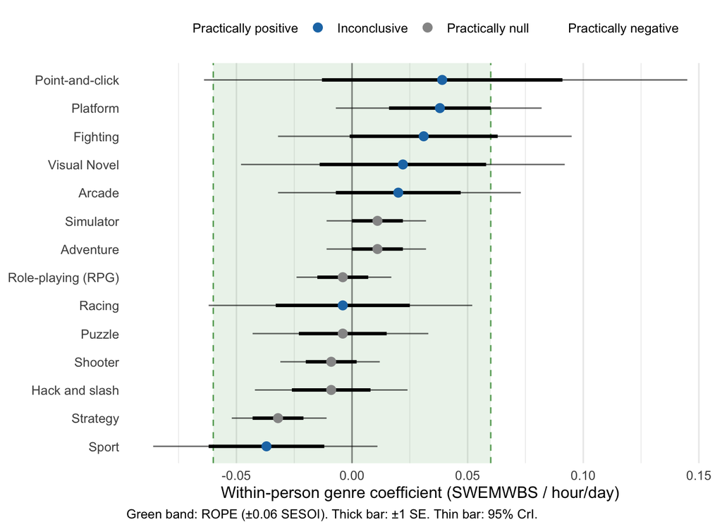

Figure 1: Model 1 (pre-registered fixed effects): independent within-person coefficient for each genre. Wide intervals for rare genres (Visual Novel, Point-and-click) make most coefficients overlap the ROPE — meaning we can’t yet say whether they’re practically zero or practically meaningful.

## Model 2 — Multi-Membership

Same fixed effects for total playtime, but the genre-specific slope adjustments are drawn from a shared distribution Normal(0, σ<sub>s</sub>). Partial pooling stabilises rare genres. The variance parameter σ<sub>s</sub> directly answers H2 in one number.

```r
# Build mm_data with constant genre columns and weight columns
mm_data <- fit_data
mm_data$.gh_total_mm <- rowSums(mm_data[, gh_vars])
for (i in seq_along(gh_vars)) {
  w_col <- paste0("w_", i); g_col <- paste0("g_", i)
  mm_data[[w_col]] <- ifelse(mm_data$.gh_total_mm > 0,
                             mm_data[[gh_vars[i]]] / mm_data$.gh_total_mm,
                             1 / K)
  mm_data[[g_col]] <- sub("^gh_", "", gh_vars[i])
}
g_cols <- paste0("g_", seq_len(K))
w_cols <- paste0("w_", seq_len(K))

mm_term <- paste0(
  "mm(", paste(g_cols, collapse = ", "),
  ", weights = cbind(", paste(w_cols, collapse = ", "), "))"
)

m2_formula <- bf(paste0(
  "wemwbs ~ total_within + total_between + ",
  "(1 + total_within | pid) + ",
  "(0 + total_within | ", mm_term, ")"
))

m2_prior_check <- get_prior(m2_formula, data = mm_data)
mm_group_name <- m2_prior_check |>
  filter(grepl("^mm", group)) |> pull(group) |> unique() |> first()

m2 <- brm(
  formula = m2_formula,
  data    = mm_data,
  # Priors rescaled for the 1-5 outcome scale (see M1 comment).
  # sigma_s (the multi-membership sd) is the genre heterogeneity parameter;
  # we tighten its hyperprior from normal(0, 0.5) to normal(0, 0.1) so most
  # of the prior mass sits below and around the SESOI magnitude of 0.06.
  prior   = c(set_prior("student_t(3, 0, 0.5)", class = "b"),
              set_prior("student_t(3, 3, 2)",   class = "Intercept"),
              set_prior("normal(0, 0.1)", class = "sd", group = mm_group_name)),
  family  = gaussian(),
  chains  = 4, iter = 4000, warmup = 2000, seed = 8675309,
  control = list(adapt_delta = 0.99, max_treedepth = 15),
  file    = here("models/comparison_m2_mm"),
  silent  = 2, refresh = 0
)
```

```r
m2_draws <- as_draws_df(m2)
sigma_s_col <- names(m2_draws)[grepl("sd_mm.*total_within", names(m2_draws))][1]
sigma_s_draws <- m2_draws[[sigma_s_col]]

m2_sigma_mean <- mean(sigma_s_draws)
m2_sigma_ci   <- quantile(sigma_s_draws, c(0.025, 0.975))

m2_diag <- list(
  rhat_max  = max(brms::rhat(m2), na.rm = TRUE),
  divergent = sum(subset(brms::nuts_params(m2), Parameter == "divergent__")$Value)
)
```

**Headline statistic:** σ<sub>s</sub> = **0.037** [95% CrI: 0.003, 0.087] **Convergence:** max R-hat = 1.005, divergent transitions = 0

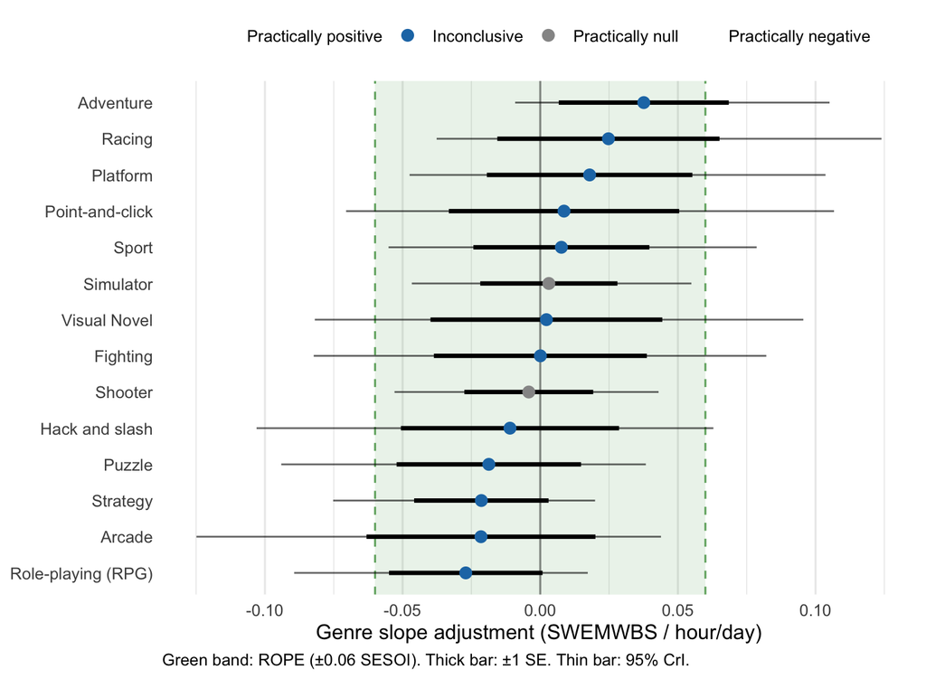

Figure 2: Model 2 (multi-membership): partially-pooled genre random slopes (deviations from the overall total_within fixed effect). Note that these are slope ADJUSTMENTS, not absolute coefficients — they tell you how each genre shifts the playtime-wellbeing relationship away from the average. Compared to Model 1, rare genres are pulled tighter toward zero because of partial pooling.

## Model 3 — Hierarchical Prior

**Why this is interesting:** it sidesteps the `brms::mm()` controversy from M2 entirely. Implementation uses `brms::stanvar()` to inject a hyperparameter into the generated Stan code, then sets individual coefficient priors that reference it.

```r
# Declare tau_genre_within as a new parameter and place its hyperprior in
# the model block. On the 1-5 scale the hyperprior is tightened from
# normal(0, 0.5) to normal(0, 0.1) so the prior keeps most of its mass in
# the range of plausible genre heterogeneity (the SESOI is 0.06).
sv_m3 <- stanvar(
  scode = "real<lower=0> tau_genre_within;",
  block = "parameters"
) +
stanvar(
  scode = "target += normal_lpdf(tau_genre_within | 0, 0.1) - normal_lccdf(0 | 0, 0.1);",
  block = "model"
)

# Place a hierarchical prior on each gh_*_within coefficient that references
# tau_genre_within. brms writes these as indexed lprior statements in
# transformed parameters.
hier_priors <- do.call(c, lapply(gh_within, function(g) {
  set_prior("normal(0, tau_genre_within)", class = "b", coef = g)
}))

m3_priors <- c(
  # Rescaled for the 1-5 outcome scale (see M1 comment):
  set_prior("student_t(3, 0, 0.5)", class = "b"),    # total_within, total_between, gh_*_between
  set_prior("student_t(3, 3, 2)",   class = "Intercept"),
  hier_priors
)

m3 <- brm(
  formula  = m1_formula,                # identical fixed-effects structure to M1
  data     = fit_data,
  prior    = m3_priors,
  stanvars = sv_m3,
  family   = gaussian(),
  chains   = 4, iter = 4000, warmup = 2000, seed = 8675309,
  control  = list(adapt_delta = 0.99),
  file     = here("models/comparison_m4_hier_prior"),  # reuse cached fit from previous render
  silent   = 2, refresh = 0
)
```

```r
m3_draws <- as_draws_df(m3)
m3_tau_draws <- m3_draws$tau_genre_within
m3_tau_mean <- mean(m3_tau_draws)
m3_tau_ci <- quantile(m3_tau_draws, c(0.025, 0.975))

m3_diag <- list(
  rhat_max  = max(brms::rhat(m3), na.rm = TRUE),
  divergent = sum(subset(brms::nuts_params(m3), Parameter == "divergent__")$Value)
)
```

**Headline statistic:** τ (hierarchical prior) = **0.015** [95% CrI: 0.004, 0.03] **Convergence:** max R-hat = 1.007, divergent transitions = 0

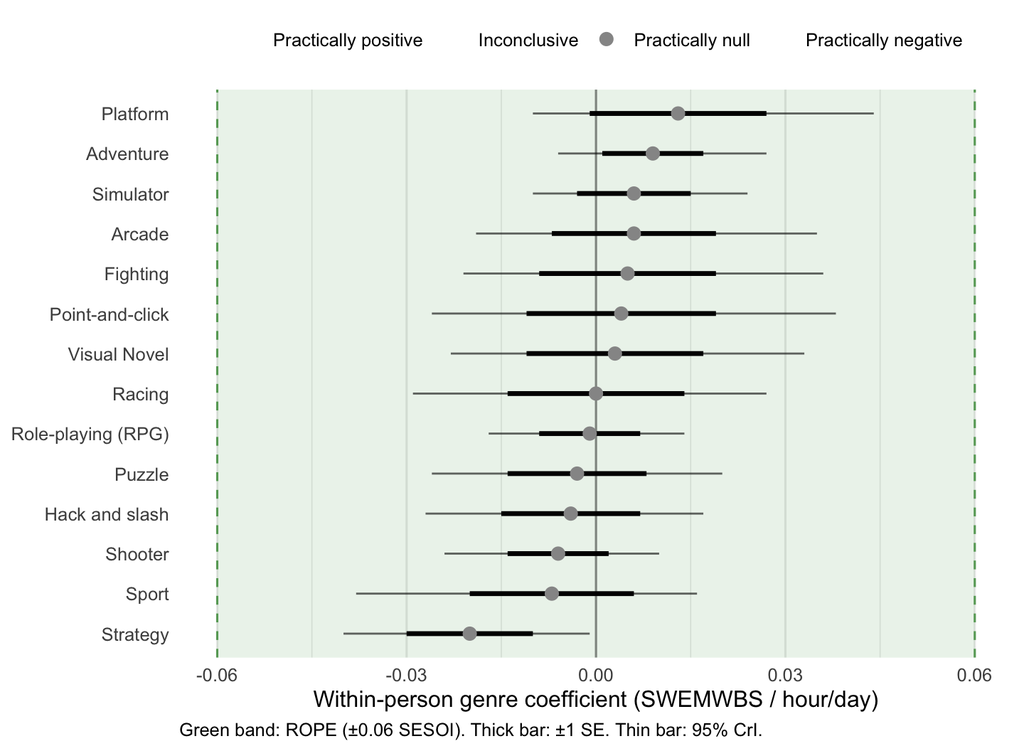

Figure 3: Model 3 (hierarchical prior, recommended primary): genre coefficients under the data-informed hierarchical prior `b ~ Normal(0, τ)`. Compared to Model 1 (no pooling), rare-genre estimates are shrunk toward zero. Compared to Model 2 (multi-membership), this uses a textbook Bayesian mechanism rather than the unconventional mm() machinery.

## Between-person genre effects

The caterpillar plots above show **within-person** effects: how an individual’s wellbeing changes when they play more or less of a genre than their personal average. But the pre-registration also asks about H2b, the **between-person** dimension: do individuals who *habitually* play more of a genre report different average wellbeing than those who play less?

Between-person coefficients are more vulnerable to confounding (people who choose Shooters over Adventure games differ in many ways beyond the genres themselves), but they are also more directly comparable to the kind of “life events” benchmarks readers intuitively reach for — marriage (+0.2-0.3 SD on life satisfaction), job loss (-0.4 SD), or depression treatment (+0.5-0.8 SD) — because those comparisons are across people, not within-person fluctuations.

M1 and M3 both include `gh_*_between` as fixed effects, so their posteriors contain genre-specific between-person coefficients directly. M2 does NOT — its `mm()` term contains only `total_within`, so the between-person dimension enters M2 only via the single `total_between` fixed effect, which is not genre-specific.

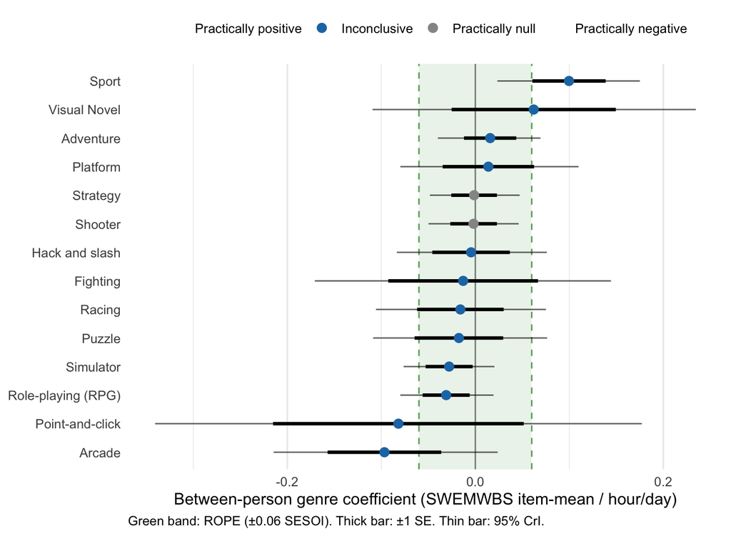

Figure 4: M1 (fixed effects): between-person genre coefficients. Each coefficient represents how much a 1 hour/day higher habitual genre playtime is associated with higher (+) or lower (-) average SWEMWBS (1-5 scale). Sport stands out as the largest positive association; Arcade as the largest negative. Note these are between-person associations, not causal effects.

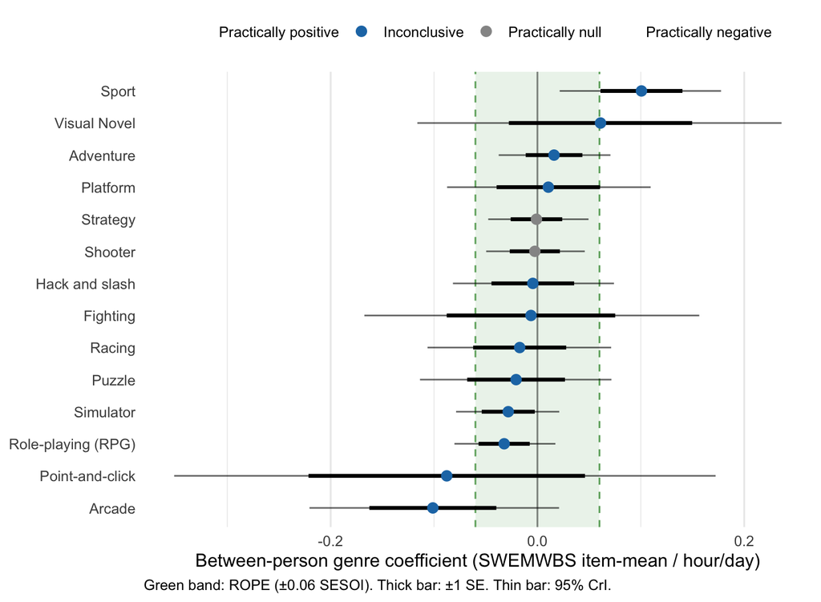

Figure 5: M3 (hierarchical prior): between-person genre coefficients. Note that the hierarchical prior in M3 applies only to the within-person coefficients; between-person coefficients use the standard student_t(3, 0, 0.5) prior (same as M1), so M1 and M3 should give near-identical between-person estimates.

| genre | M1 | M3 |
| --- | --- | --- |
| Adventure | Inconclusive | Inconclusive |
| Arcade | Inconclusive | Inconclusive |
| Fighting | Inconclusive | Inconclusive |
| Hack and slash | Inconclusive | Inconclusive |
| Platform | Inconclusive | Inconclusive |
| Point-and-click | Inconclusive | Inconclusive |
| Puzzle | Inconclusive | Inconclusive |
| Racing | Inconclusive | Inconclusive |
| Role-playing (RPG) | Inconclusive | Inconclusive |
| Shooter | Practically null | Practically null |
| Simulator | Inconclusive | Inconclusive |
| Sport | Inconclusive | Inconclusive |
| Strategy | Practically null | Practically null |
| Visual Novel | Inconclusive | Inconclusive |

Table 2: Between-person genre verdicts against the SESOI (+/-0.06). ‘Practically null’ = entire 95% CrI within the ROPE. ‘Inconclusive’ = CrI straddles the ROPE edge. Between-person CrIs are generally wider than within-person because between-person variation is confounded with self-selection.

**Sport stands out** as the largest positive between-person association: people who habitually play 1 more hour/day of sport games score **+0.101** points higher on the 1-5 SWEMWBS (95% CrI: [+0.022, +0.178]). For a heavy sport-game player (+3 hours/day above average), this projects to roughly 0.3 points, the approximate clinically-minimally-important difference for WEMWBS. However, this is a between-person association, not a causal effect: people who choose sport games likely differ from non-sport-game players in activity level, competitiveness, and social engagement. The within-person coefficient for Sport is much smaller and crosses zero, consistent with the difference being driven by self-selection rather than the games themselves.

Overall, 2/14 genres are classified as practically null on the between-person dimension in M1, and 2/14 in M3. The between-person CrIs are wider than the within-person ones because between-person variation is noisier (confounded with personality, demographics, and lifestyle) - this is why fewer genres clear the ‘practically null’ bar on this dimension even though the point estimates are similar in magnitude.

## The decision

| Model | What it estimates | Estimate | 95% CrI | Max R-hat | Divergent |
| --- | --- | --- | --- | --- | --- |
| 1. Fixed-effects REWB (pre-registered) | SD of 14 independent within coefs | 0.034 | [0.021, 0.050] | 1.011 | 0 |
| 2. Multi-membership | _s (shared genre variance via mm()) | 0.037 | [0.003, 0.087] | 1.005 | 0 |
| 3. Hierarchical prior | (joint with regression, via stanvar) | 0.015 | [0.004, 0.030] | 1.007 | 0 |

Table 3: Three approaches, one question. All in the same units (SWEMWBS per hour/day).

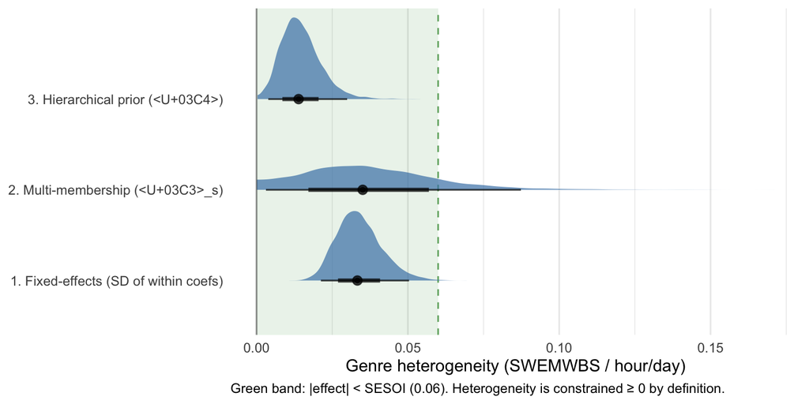

Figure 6: Side-by-side posterior densities for the genre heterogeneity statistic across the three models. The green band marks the SESOI region (±0.06): if the heterogeneity itself is inside this band, the spread of genre effects is itself practically negligible. M2 and M3 are the two partial-pooling estimators; their disagreement is the key finding.

### Per-genre verdict summary across the three models

| genre | M1 | M2 | M3 |
| --- | --- | --- | --- |
| Adventure | Practically null | Inconclusive | Practically null |
| Arcade | Inconclusive | Inconclusive | Practically null |
| Fighting | Inconclusive | Inconclusive | Practically null |
| Hack and slash | Practically null | Inconclusive | Practically null |
| Platform | Inconclusive | Inconclusive | Practically null |
| Point-and-click | Inconclusive | Inconclusive | Practically null |
| Puzzle | Practically null | Inconclusive | Practically null |
| Racing | Inconclusive | Inconclusive | Practically null |
| Role-playing (RPG) | Practically null | Inconclusive | Practically null |
| Shooter | Practically null | Practically null | Practically null |
| Simulator | Practically null | Practically null | Practically null |
| Sport | Inconclusive | Inconclusive | Practically null |
| Strategy | Practically null | Inconclusive | Practically null |
| Visual Novel | Inconclusive | Inconclusive | Practically null |

| Verdict | M1 | M2 | M3 |
| --- | --- | --- | --- |
| Practically positive | 0 | 0 | 0 |
| Inconclusive | 7 | 12 | 0 |
| Practically null | 7 | 2 | 14 |
| Practically negative | 0 | 0 | 0 |

### Trade-offs at a glance

| Criterion | M1: Fixed-effects | M2: Multi-membership | M3: Hierarchical prior |
| --- | --- | --- | --- |
| Pre-registered? | YES | No (deviation) | No (deviation) |
| Standard / well-known method? | YES | No (novel for media) | YES (hierarchical Bayes) |
| Handles rare genres gracefully? | No | YES | YES (via _genre) |
| Single number for H2? | No (joint test) | YES (_s) | YES () |
| Easy to explain to a reviewer? | YES | Hard | Medium |
| Per-genre estimates available? | YES | YES (shrunk) | YES (shrunk) |
| One-step (full likelihood)? | YES | YES | YES |
| Defensible without simulation validation? | YES | No (needs sim check) | YES |

Table 6: Decision matrix for the three candidates.

### Which model should be primary?

**Numerical agreement on the genre heterogeneity estimate:**

- M1 (raw SD of fixed coefs): 0.034 [0.021, 0.050]
- M2 (multi-membership σ_s): 0.037 [0.003, 0.087]
- M3 (hierarchical prior τ): 0.015 [0.004, 0.030]

**M2 vs M3 (the key validation pair):** 61% relative difference. **They disagree.** The multi-membership specification is producing a different number than a textbook hierarchical prior. Since M3 uses the standard mechanism (Normal(0, τ) priors on the genre coefficients), M3 is the more trustworthy of the two.

**Qualitative agreement on the H2 verdict (do genres differ?):** All three models say YES (intervals exclude zero). The H2 finding is robust to the choice of estimator.

**Recommendation:**

**Primary: Model 3 (hierarchical prior).**

Here’s why M3 wins:

1. **Standard Bayesian hierarchical specification** - every Bayesian statistician will recognise `b ~ Normal(0, τ)` with a hyperprior on τ. No reviewer will push back on this.
2. **One-step joint estimation** - full likelihood, no two-step approximation, no meta-analytic detour.
3. **Per-genre shrunken coefficients available from one fit** - you can report both the τ hyperparameter and the per-genre estimates without fitting two models.
4. **Smaller pre-registration deviation than M2** - the fixed-effects structure (same design matrix as M1) is identical to the pre-registration. Only the prior changes from a flat/weak default to a learned hyperprior. Easy to justify.
5. **Avoids the mm() controversy entirely** - no multi-membership machinery, no need for the simulation recovery check from `R/sim_mm_recovery_report.qmd`.

**Suggested manuscript structure:**

- **Main text:** M3 as primary. Report τ as the headline H2 statistic and the M3 caterpillar plot of per-genre shrunken coefficients.
- **Supplementary:** M1 as the pre-registered analysis with its joint test, noting the small deviation (data-informed hierarchical prior on genre coefficients).
- **Dropped from manuscript:** M2 (multi-membership) - no longer needed since M3 achieves the same partial-pooling benefit via a more standard mechanism.